# Bm_final_project

Yi Xiao

10/12/2018

```r
library(tidyverse)
```

```r
library(kableExtra)
library(Hmisc)
```

```r
library(kableExtra)
library(Hmisc)
```

1. load the dataset

```r
cancer_data <- read_csv("./data/Cancer_Registry.csv") %>%
        janitor::clean_names()
```

The Cancer Registry Dataset cantains information on cancer mortality rate across 3047 US counties. There are 34 variables which provide information on death rate and related demographical characteristics in each county. The outcome variable in this datset is `target_death rate` (continuous).

2. explore the data

```r
# 1. deal with missing data

num_var <- cancer_data %>%
        select(-c(binned_inc, geography))
# summary table for all numberical variables:
num_var %>%
        skimr::skim_to_wide() %>% knitr::kable() %>% kable_styling(full_width = F, position = "left")
```

| type | variable | missing | complete | n | mean | sd | p0 | p25 | p50 | p75 | p100 | hist |
| --- | --- | --- | --- | --- | --- | --- | --- | --- | --- | --- | --- | --- |
| integer | avg_deaths_per_year | 0 | 3047 | 3047 | 185.97 | 504.13 | 3 | 28 | 61 | 149 | 14010 | ▇▁▁▁▁▁▁▁ |
| integer | med_income | 0 | 3047 | 3047 | 47063.28 | 12040.09 | 22640 | 38882.5 | 45207 | 52492 | 125635 | ▂▇▅▁▁▁▁▁ |
| integer | pop_est2015 | 0 | 3047 | 3047 | 1e+05 | 329059.22 | 827 | 11684 | 26643 | 68671 | 1e+07 | ▇▁▁▁▁▁▁▁ |
| numeric | avg_ann_count | 0 | 3047 | 3047 | 606.34 | 1416.36 | 6 | 76 | 171 | 518 | 38150 | ▇▁▁▁▁▁▁▁ |
| numeric | avg_household_size | 0 | 3047 | 3047 | 2.48 | 0.43 | 0.022 | 2.37 | 2.5 | 2.63 | 3.97 | ▁▁▁▁▇▇▁▁ |
| numeric | birth_rate | 0 | 3047 | 3047 | 5.64 | 1.99 | 0 | 4.52 | 5.38 | 6.49 | 21.33 | ▁▇▇▂▁▁▁▁ |
| numeric | incidence_rate | 0 | 3047 | 3047 | 448.27 | 54.56 | 201.3 | 420.3 | 453.55 | 480.85 | 1206.9 | ▁▇▇▁▁▁▁▁ |
| numeric | median_age | 0 | 3047 | 3047 | 45.27 | 45.3 | 22.3 | 37.7 | 41 | 44 | 624 | ▇▁▁▁▁▁▁▁ |
| numeric | median_age_female | 0 | 3047 | 3047 | 42.15 | 5.29 | 22.3 | 39.1 | 42.4 | 45.3 | 65.7 | ▁▁▃▇▅▁▁▁ |
| numeric | median_age_male | 0 | 3047 | 3047 | 39.57 | 5.23 | 22.4 | 36.35 | 39.6 | 42.5 | 64.7 | ▁▂▆▇▃▁▁▁ |
| numeric | pct_asian | 0 | 3047 | 3047 | 1.25 | 2.61 | 0 | 0.25 | 0.55 | 1.22 | 42.62 | ▇▁▁▁▁▁▁▁ |
| numeric | pct_bach_deg18_24 | 0 | 3047 | 3047 | 6.16 | 4.53 | 0 | 3.1 | 5.4 | 8.2 | 51.8 | ▇▅▁▁▁▁▁▁ |
| numeric | pct_bach_deg25_over | 0 | 3047 | 3047 | 13.28 | 5.39 | 2.5 | 9.4 | 12.3 | 16.1 | 42.2 | ▂▇▆▃▁▁▁▁ |
| numeric | pct_black | 0 | 3047 | 3047 | 9.11 | 14.53 | 0 | 0.62 | 2.25 | 10.51 | 85.95 | ▇▁▁▁▁▁▁▁ |
| numeric | pct_emp_priv_coverage | 0 | 3047 | 3047 | 41.2 | 9.45 | 13.5 | 34.5 | 41.1 | 47.7 | 70.7 | ▁▂▆▇▇▅▁▁ |
| numeric | pct_employed16_over | 152 | 2895 | 3047 | 54.15 | 8.32 | 17.6 | 48.6 | 54.5 | 60.3 | 80.1 | ▁▁▁▅▇▇▂▁ |
| numeric | pct_hs18_24 | 0 | 3047 | 3047 | 35 | 9.07 | 0 | 29.2 | 34.7 | 40.7 | 72.5 | ▁▁▃▇▆▂▁▁ |
| numeric | pct_hs25_over | 0 | 3047 | 3047 | 34.8 | 7.03 | 7.5 | 30.4 | 35.3 | 39.65 | 54.8 | ▁▁▂▅▇▆▂▁ |
| numeric | pct_married_households | 0 | 3047 | 3047 | 51.24 | 6.57 | 22.99 | 47.76 | 51.67 | 55.4 | 78.08 | ▁▁▂▆▇▂▁▁ |
| numeric | pct_no_hs18_24 | 0 | 3047 | 3047 | 18.22 | 8.09 | 0 | 12.8 | 17.1 | 22.7 | 64.1 | ▂▇▇▃▁▁▁▁ |
| numeric | pct_other_race | 0 | 3047 | 3047 | 1.98 | 3.52 | 0 | 0.3 | 0.83 | 2.18 | 41.93 | ▇▁▁▁▁▁▁▁ |
| numeric | pct_private_coverage | 0 | 3047 | 3047 | 64.35 | 10.65 | 22.3 | 57.2 | 65.1 | 72.1 | 92.3 | ▁▁▂▅▇▇▅▁ |
| numeric | pct_private_coverage_alone | 609 | 2438 | 3047 | 48.45 | 10.08 | 15.7 | 41 | 48.7 | 55.6 | 78.9 | ▁▁▅▇▇▅▂▁ |
| numeric | pct_public_coverage | 0 | 3047 | 3047 | 36.25 | 7.84 | 11.2 | 30.9 | 36.3 | 41.55 | 65.1 | ▁▂▅▇▇▃▁▁ |
| numeric | pct_public_coverage_alone | 0 | 3047 | 3047 | 19.24 | 6.11 | 2.6 | 14.85 | 18.8 | 23.1 | 46.6 | ▁▃▇▇▃▁▁▁ |
| numeric | pct_some_col18_24 | 2285 | 762 | 3047 | 40.98 | 11.12 | 7.1 | 34 | 40.4 | 46.4 | 79 | ▁▁▅▇▅▂▁▁ |
| numeric | pct_unemployed16_over | 0 | 3047 | 3047 | 7.85 | 3.45 | 0.4 | 5.5 | 7.6 | 9.7 | 29.4 | ▂▇▇▂▁▁▁▁ |
| numeric | pct_white | 0 | 3047 | 3047 | 83.65 | 16.38 | 10.2 | 77.3 | 90.06 | 95.45 | 100 | ▁▁▁▁▁▂▃▇ |
| numeric | percent_married | 0 | 3047 | 3047 | 51.77 | 6.9 | 23.1 | 47.75 | 52.4 | 56.4 | 72.5 | ▁▁▁▅▇▇▂▁ |
| numeric | poverty_percent | 0 | 3047 | 3047 | 16.88 | 6.41 | 3.2 | 12.15 | 15.9 | 20.4 | 47.4 | ▂▇▇▅▂▁▁▁ |
| numeric | study_per_cap | 0 | 3047 | 3047 | 155.4 | 529.63 | 0 | 0 | 0 | 83.65 | 9762.31 | ▇▁▁▁▁▁▁▁ |
| numeric | target_death_rate | 0 | 3047 | 3047 | 178.66 | 27.75 | 59.7 | 161.2 | 178.1 | 195.2 | 362.8 | ▁▁▆▇▂▁▁▁ |

```r
cancer_data %>%
   select(geography,binned_inc) %>%
describe()
```

```
## .
##
##  2  Variables      3047  Observations
## ---------------------------------------------------------------------------
## geography
##        n  missing distinct
##     3047        0     3047
##
## lowest : Abbeville County, South Carolina  Acadia Parish, Louisiana          Accomack County, Virginia         Ada County, Idaho                 Adair County, Iowa
## highest: Yukon-Koyukuk Census Area, Alaska Yuma County, Arizona              Yuma County, Colorado             Zapata County, Texas              Zavala County, Texas
## ---------------------------------------------------------------------------
## binned_inc
##        n  missing distinct
##     3047        0       10
##
## (34218.1, 37413.8] (304, 0.100), (37413.8, 40362.7] (304, 0.100),
## (40362.7, 42724.4] (304, 0.100), (42724.4, 45201] (305, 0.100), (45201,
## 48021.6] (306, 0.100), (48021.6, 51046.4] (305, 0.100), (51046.4, 54545.6]
## (305, 0.100), (54545.6, 61494.5] (306, 0.100), (61494.5, 125635] (302,
## 0.099), [22640, 34218.1] (306, 0.100)
## ---------------------------------------------------------------------------
```

```r
# presence of large amount of missing data (over 20%)  in two variabls: pct_some_col18_24 and pct_private_coverage_alone
# remove those two variables
```

```r
# 2. check normality
ggplot(gather(num_var), aes(value)) +
    geom_histogram(bins = 10) +
    facet_wrap(~key, scales = 'free_x')
```

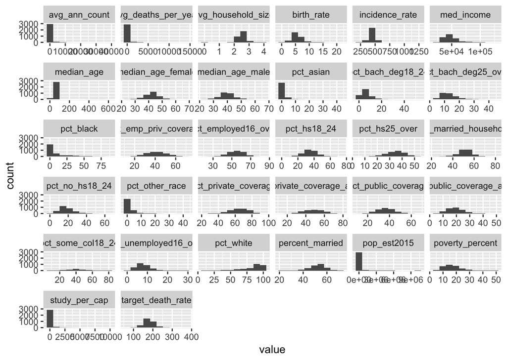

```r
# check colinearity
colin = cor(num_var)
```

[figure not shown]

```r
# check colinearity
colin = cor(num_var)
```

some comments: 1. med_income and poverty_percent: high colinearity & basically the same thing: consider removing one of them 2.avg-ann-count and population / avg_death and population: duplicate information with “incidence” and the outcome variable: remove?

3. tidy

```r
cancer_tidy_data = cancer_data %>%
        separate(geography, into = c("county", "state"), sep = ", ") %>%
        mutate(
                binned_inc_lowerb = str_split_fixed(binned_inc, ", ", 2)[ ,1] %>% parse_number(),
                binned_inc_upperb = str_split_fixed(binned_inc, ", ", 2)[ ,2] %>% parse_number(),
                binned_inc_mean = (binned_inc_lowerb + binned_inc_upperb)/2
                ) %>%# calculate point estimate for variable binned_inc
         # counties were categorized according to census region
        mutate(region = case_when(
            state %in% c("Montana", "Arizona","Idaho","Colorado", "New     Mexico","Utah","Nevada","Wyoming","Alaska","California",
            "Hawaii","Oregon","Washington") ~ "West",
            state %in% c("Illinois","Indiana", "Michigan","Iowa","Ohio", "Kansas","Minnesota","Missouri","Wisconsin", "Nebraska","North Dakota","South Dakota") ~ "Midwest",
            state %in% c("District of Columbia", "Delaware","Georgia",
            "Maryland", "North Carolina","Florida","South Carolina",
            "West Virginia","Kentucky", "Alabama","Virginia","Mississippi", "Arkansas","Tennessee","Louisiana","Oklahoma","Texas") ~ "South",
             state %in%  c("Connecticut","Maine","Massachusetts","New Hampshire",
             "Rhode Island","Vermont","New Jersey","New York",
             "Pennsylvania") ~ "Northeast" ), region = as.factor(region) %>% fct_relevel(., "West", "Midwest", "Northeast", "South")) %>%
        mutate(income_cate = case_when(med_income < 35000 ~ "category1",
                                       med_income >=35000 & med_income < 42999 ~ "category2",
                                        med_income >= 43000 & med_income <= 52999 ~ "category3",
                                        med_income >= 53000 & med_income <= 62999~ "category4",
                                        med_income >= 63000  ~"category5"), income_cate = fct_relevel(income_cate, c("category1", "category2", "category3", "category4", "category5")))

describe(cancer_tidy_data$income_cate)
```

```
## cancer_tidy_data$income_cate
##        n  missing distinct
##     3047        0        5
##
## Value      category1 category2 category3 category4 category5
## Frequency        378       877      1085       459       248
## Proportion     0.124     0.288     0.356     0.151     0.081
```

Reference: 1. geographocal distribution of cancer mortality https://www.cancer.gov/news-events/cancer-currents-blog/2017/cancer-death-disparities

2. social disparity: https://www.ncbi.nlm.nih.gov/pubmed/28718431
3. socialeconomic factor https://www.ncbi.nlm.nih.gov/pmc/articles/PMC2711979/